# Standardising a realistic logbook: two worked examples

### Effects and vessels

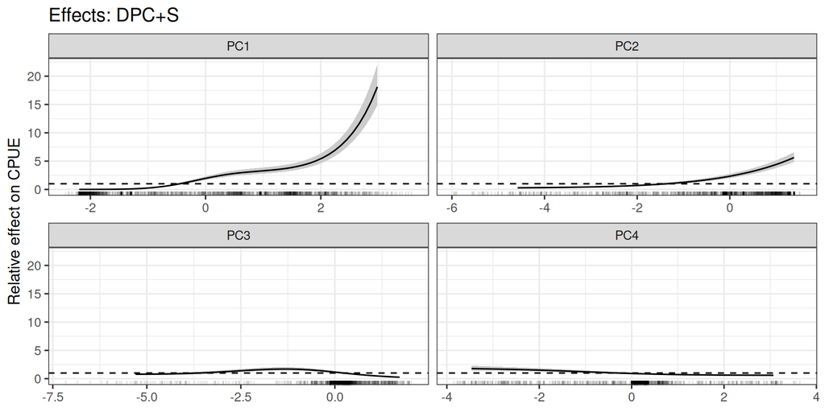

```r
eff <- plot_effects(fit_sbr, "DPC+S")
eff$numeric
```

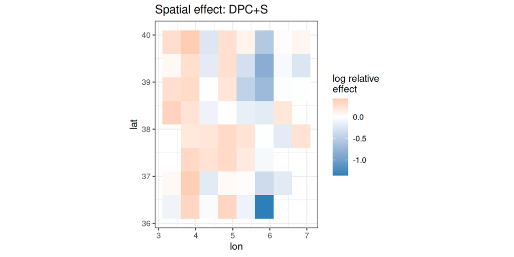

```r
eff$space
```

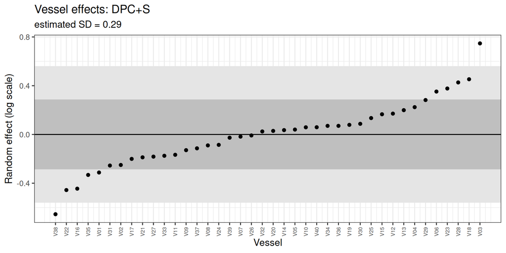

```r
plot_vessel_effects(fit_sbr, "DPC+S")
```

> **Guidelines**
> - A targeting term that matters shows **influence that changes over time**.
> - Residuals should show **no trend by year** and no pattern by tactic.
> - The error distribution should reproduce the **zeros and the upper tail by year**.
> - Compare **DPC and Cluster**; if they disagree, look at the PCs over time and ask whether relative abundances may have diverged.

### Sensitivity to the data selection

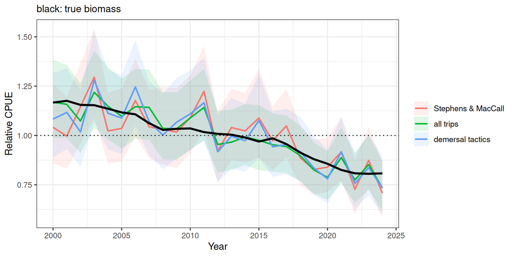

```r
fit_sbr_all <- fit_cpue(x, species = "Pagellus bogaraveo", models = "DPC+S",
                        vessel = TRUE, spatial_k = 40, engine = "bam")
x_sm <- add_targeting(subset(x, sm$selected, note = "Stephens & MacCall, seabream"))
fit_sbr_sm <- fit_cpue(x_sm, species = "Pagellus bogaraveo", models = "DPC+S",
                       vessel = TRUE, spatial_k = 40, engine = "bam")
compare_indices(list(`demersal tactics` = list(fit = fit_sbr, model = "DPC+S"),
                     `Stephens & MacCall` = list(fit = fit_sbr_sm, model = "DPC+S"),
                     `all trips` = list(fit = fit_sbr_all, model = "DPC+S")),
                true_sbr)
```

## Step 9. The index

```r
idx_sbr <- cpue_index(fit_sbr, "DPC+S")
knitr::kable(idx_sbr, digits = 3)
```

| year | n | nominal | index | relative | se_log | cv | lower | upper |
| --- | --- | --- | --- | --- | --- | --- | --- | --- |
| 2000 | 130 | 3.859 | 2.112 | 1.083 | 0.100 | 0.100 | 0.891 | 1.317 |
| 2001 | 188 | 3.607 | 2.177 | 1.117 | 0.093 | 0.093 | 0.930 | 1.341 |
| 2002 | 168 | 3.587 | 1.985 | 1.018 | 0.096 | 0.096 | 0.843 | 1.229 |
| 2003 | 200 | 3.736 | 2.494 | 1.279 | 0.091 | 0.091 | 1.070 | 1.529 |
| 2004 | 222 | 3.153 | 2.169 | 1.113 | 0.092 | 0.092 | 0.929 | 1.332 |
| 2005 | 257 | 2.513 | 2.122 | 1.088 | 0.093 | 0.093 | 0.907 | 1.307 |
| 2006 | 325 | 2.766 | 2.430 | 1.246 | 0.089 | 0.089 | 1.048 | 1.483 |
| 2007 | 299 | 2.767 | 2.086 | 1.070 | 0.089 | 0.089 | 0.899 | 1.274 |
| 2008 | 205 | 2.499 | 1.954 | 1.002 | 0.097 | 0.097 | 0.829 | 1.211 |
| 2009 | 220 | 2.373 | 2.080 | 1.067 | 0.098 | 0.098 | 0.881 | 1.292 |
| 2010 | 214 | 2.944 | 2.164 | 1.110 | 0.092 | 0.093 | 0.926 | 1.330 |
| 2011 | 241 | 2.898 | 2.273 | 1.166 | 0.092 | 0.092 | 0.974 | 1.395 |
| 2012 | 258 | 1.990 | 1.789 | 0.918 | 0.094 | 0.094 | 0.763 | 1.104 |
| 2013 | 318 | 2.181 | 1.942 | 0.996 | 0.091 | 0.091 | 0.833 | 1.191 |
| 2014 | 364 | 2.099 | 1.898 | 0.974 | 0.090 | 0.090 | 0.817 | 1.160 |
| 2015 | 197 | 2.255 | 2.098 | 1.076 | 0.099 | 0.100 | 0.885 | 1.307 |
| 2016 | 214 | 3.713 | 1.838 | 0.942 | 0.089 | 0.089 | 0.791 | 1.122 |
| 2017 | 239 | 3.863 | 1.861 | 0.954 | 0.088 | 0.089 | 0.802 | 1.135 |
| 2018 | 207 | 3.927 | 1.791 | 0.919 | 0.090 | 0.090 | 0.770 | 1.096 |
| 2019 | 210 | 3.439 | 1.630 | 0.836 | 0.091 | 0.091 | 0.700 | 0.998 |
| 2020 | 260 | 3.077 | 1.521 | 0.780 | 0.089 | 0.089 | 0.656 | 0.929 |
| 2021 | 221 | 3.152 | 1.789 | 0.917 | 0.091 | 0.092 | 0.767 | 1.097 |
| 2022 | 192 | 2.998 | 1.476 | 0.757 | 0.095 | 0.095 | 0.628 | 0.912 |
| 2023 | 176 | 3.258 | 1.631 | 0.837 | 0.094 | 0.094 | 0.696 | 1.005 |
| 2024 | 137 | 2.908 | 1.432 | 0.735 | 0.102 | 0.102 | 0.602 | 0.897 |

```r
export_index(fit_sbr, "seabream_index_DPC.csv", model = "DPC+S")
```

# Part 3. Worked example: dolphinfish

```r
true_dol <- logbook_truth(sim, "Coryphaena hippurus")
```

## Step 5. Keep the pelagic trips

```r
xp <- select_tactics(x, species = pelagic, min_share = 0.5)
round(xp$targeting$previous$share, 2)
```

```
##    1    2    3    4
## 0.59 0.94 0.06 0.06
```

```r
tail(xp$log, 3)
```

```
##             step operations
## 4  add targeting      19218
## 5 select tactics      13556
## 6  add targeting      13556
##                                                                               note
## 4                     3 PC(s) used (OC test: 3), 4 clusters (clara on composition)
## 5 clusters 1, 2 kept (clusters with >= 50% of catch from 4 species) (5662 removed)
## 6                     2 PC(s) used (OC test: 2), 3 clusters (clara on composition)
```

Outside its habitat (demersal trips) a zero says nothing about dolphinfish abundance, and the PCA of the remaining trips can now describe the targeting among pelagic species.

## Step 6. Targeting covariates of the pelagic trips

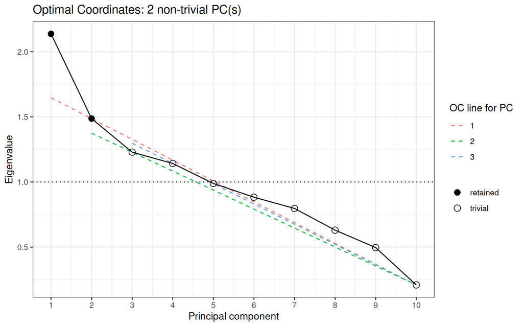

```r
plot_oc(xp)
```

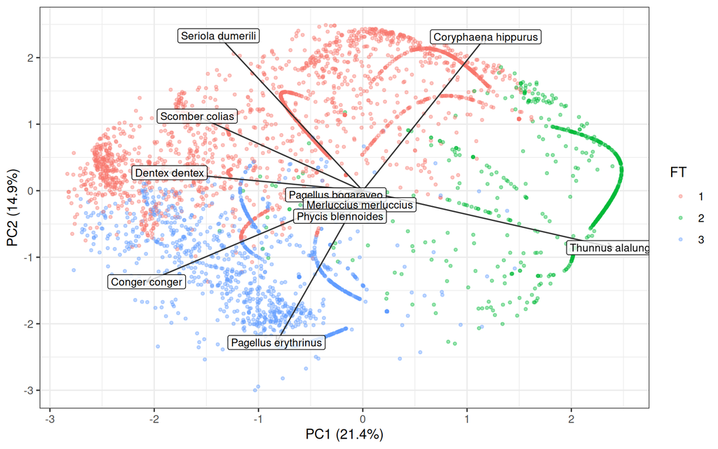

```r
plot_biplot(xp)
```

```r
tactic_table(xp)
```

```
##   FT operations share            dominant Scomber colias Seriola dumerili
## 1  1       6558 0.484      Scomber colias           48.3             14.3
## 2  2       3507 0.259    Thunnus alalunga            2.0              1.5
## 3  3       3491 0.258 Pagellus erythrinus           10.1              4.5
##   Conger conger Thunnus alalunga Coryphaena hippurus Pagellus erythrinus
## 1           8.4              1.1                11.9                 0.4
## 2           1.2             82.3                 9.3                 0.8
## 3          16.8              0.7                 1.3                56.4
##   Pagellus bogaraveo Merluccius merluccius Phycis blennoides Dentex dentex
## 1                0.6                   0.6               0.2          14.4
## 2                0.6                   0.7               0.4           1.2
## 3                0.3                   0.4               0.3           9.3
```

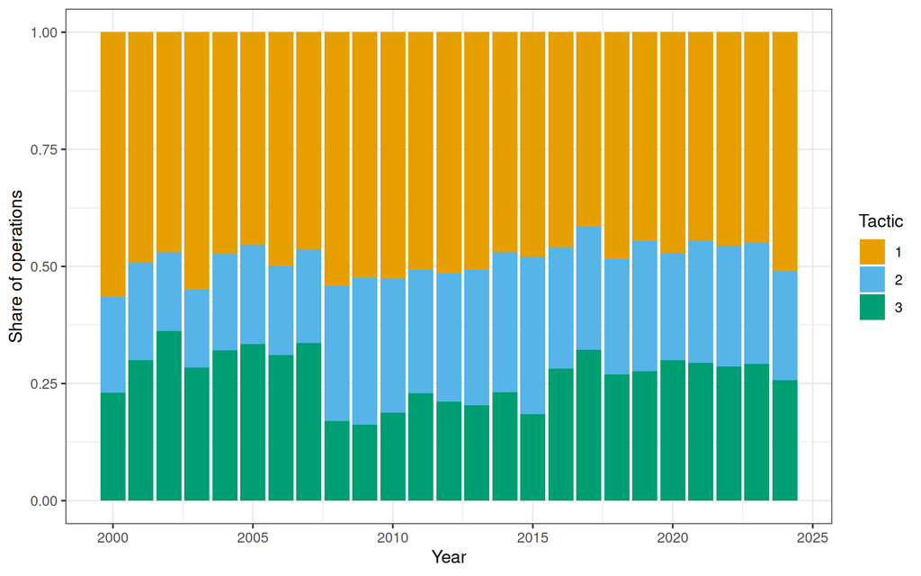

```r
pp_t <- plot_targeting(xp, by = "month", res = 0.5)
pp_t$time
```

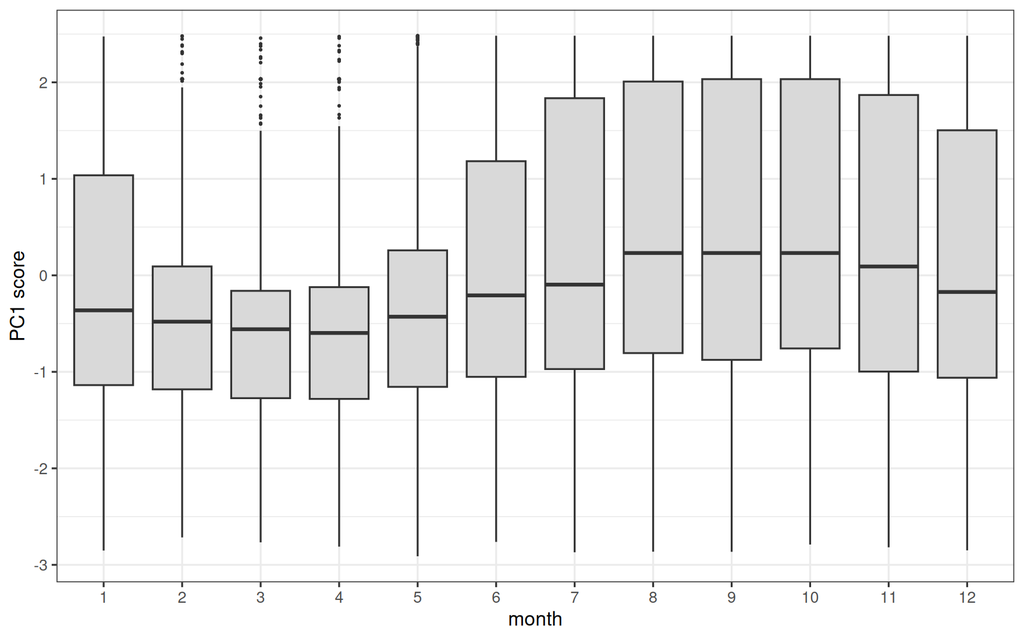

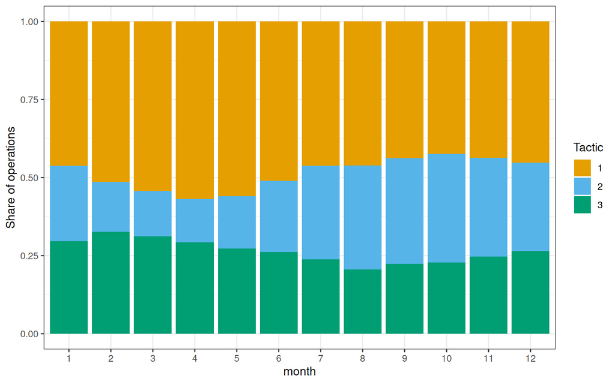

```r
pp_t$by
```

The PCs should now separate offshore species (albacore, dolphinfish) from coastal ones (amberjack, mackerel); check the loadings.

## Step 7. Fit the models

Month enters as a cyclic smoother in every model except `Base`; the index is averaged over the observed months.

```r
fit_dol <- fit_cpue(xp, species = "Coryphaena hippurus",
                    models = c("Base", "Covariates", "Cluster+S", "DPC+S"),
                    terms = 's(month, bs = "cc", k = 6)',
                    knots = list(month = c(0.5, 12.5)),
                    vessel = TRUE, spatial_k = 40, engine = "bam")
fit_dol
```

```
## <cpue_fit> Coryphaena hippurus - tweedie with random vessel effects
##   operations: 13556 ; years: 2000 - 2024
##   index averaged over: FT, month (and positions in spatial models)
## Models:
##   Base         y ~ fyear + s(vessel_re, bs = "re")
##   Covariates   y ~ fyear + s(month, bs = "cc", k = 6) + s(vessel_re, bs = "re")
##   Cluster+S    y ~ fyear + s(pos_x, pos_y, k = 40) + s(month, bs = "cc", k = 6) + FT + s(vessel_re, bs = "re")
##   DPC+S        y ~ fyear + s(pos_x, pos_y, k = 40) + s(month, bs = "cc", k = 6) + s(PC1, k = 4) + s(PC2, k = 4) + s(vessel_re, bs = "re")
```

## Step 8. Diagnostics

### Model comparison, indices and steps

```r
cpue_diagnostics(fit_dol)
```

```
##        model component     n     AIC     BIC dev_explained   edf tweedie_p
## 1       Base      main 13556 37249.9 37741.3        0.0942  63.3     1.475
## 2 Covariates      main 13556 35952.8 36474.2        0.2232  67.3     1.458
## 3  Cluster+S      main 13556 30827.6 31619.3        0.6068 103.1     1.379
## 4      DPC+S      main 13556 24100.8 24891.8        0.8239 102.8     1.332
##   vessel_sd    dAIC
## 1     0.819 13149.1
## 2     0.796 11852.0
## 3     0.585  6726.8
## 4     0.254     0.0
```

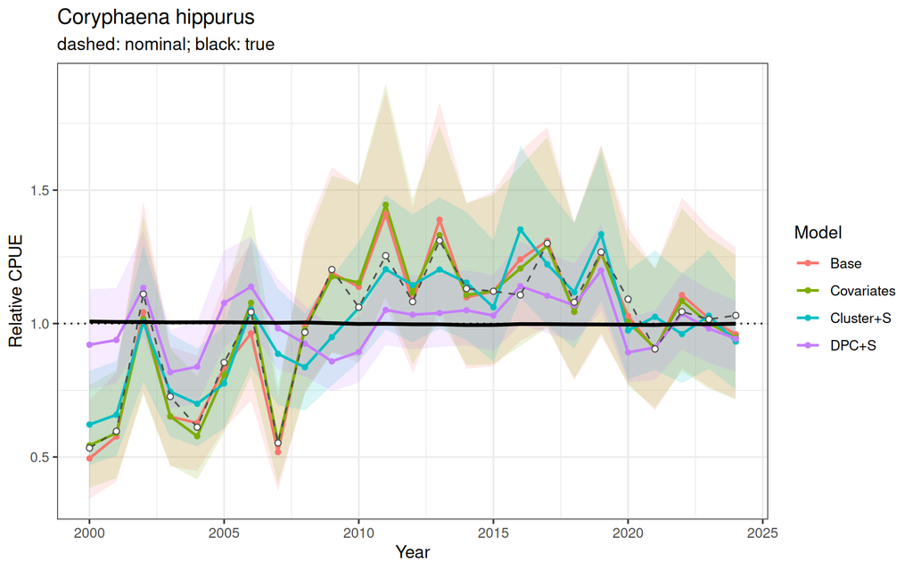

```r
plot_index(fit_dol, true = true_dol)
```

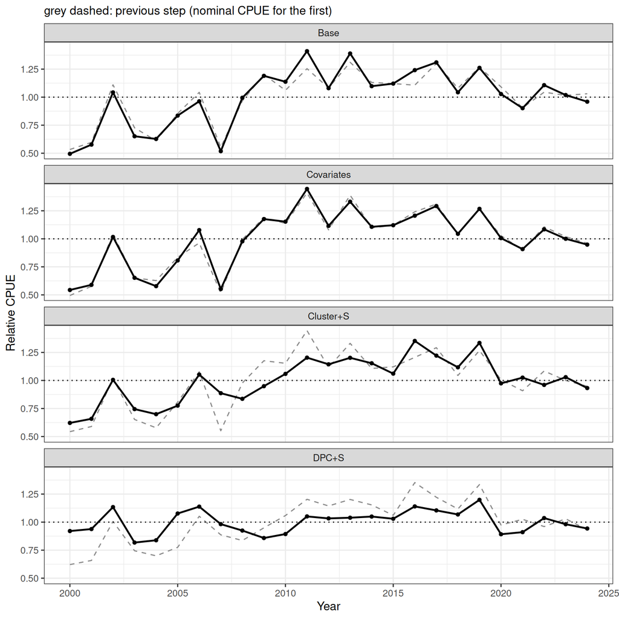

```r
plot_step(fit_dol)
```

### Influence and residuals

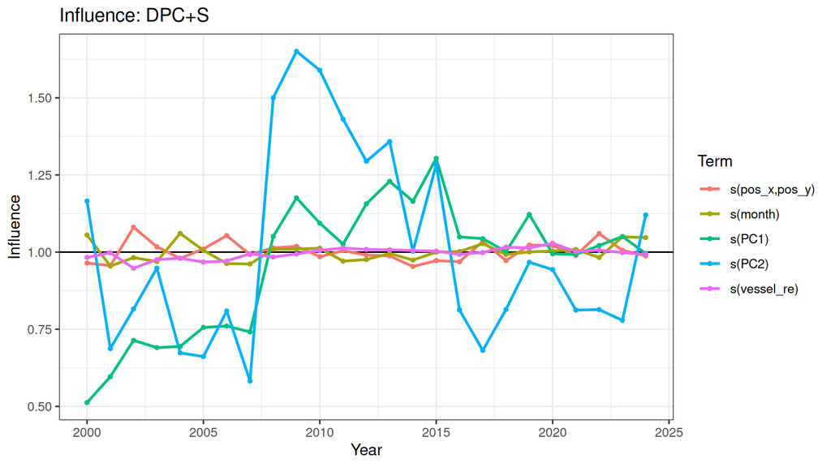

```r
plot_influence(fit_dol, "DPC+S")
```

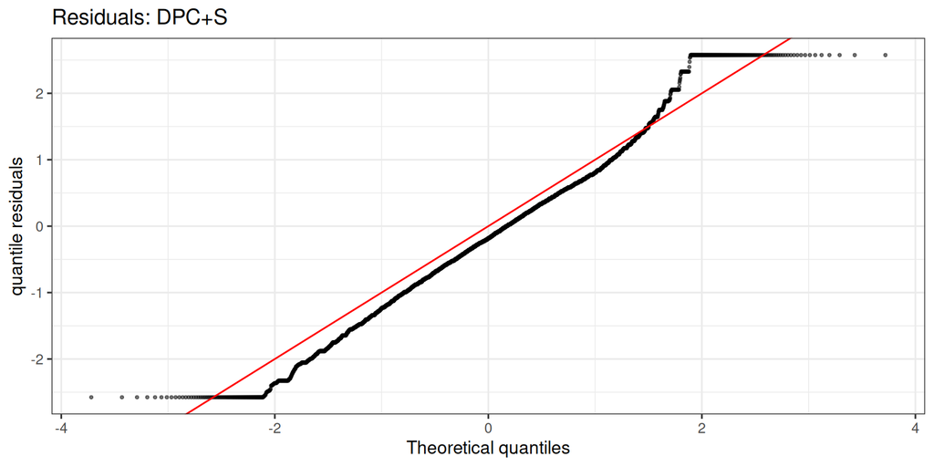

```r
res_dol <- plot_residuals(fit_dol, "DPC+S", by = "month")
res_dol$qq
```

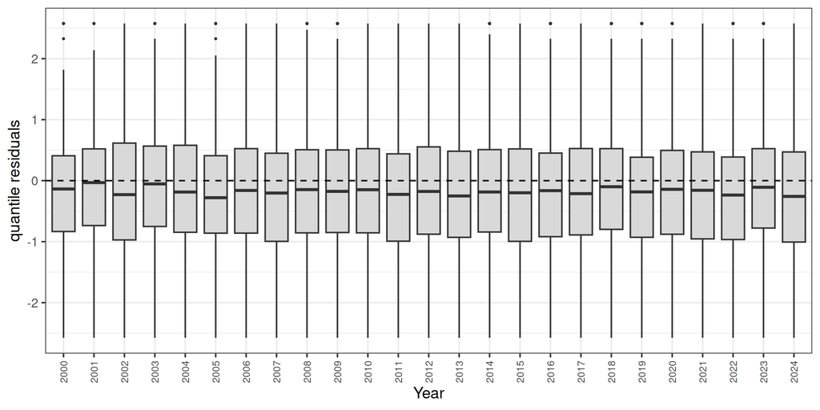

```r
res_dol$year
```

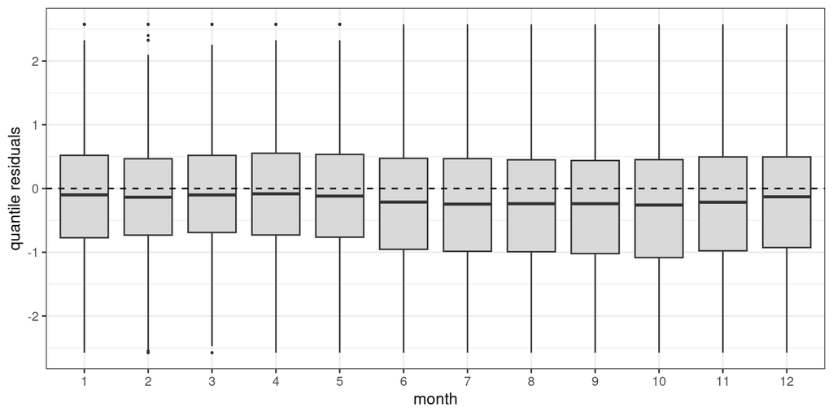

```r
res_dol$by
```

### Predictive check by month and by year

For a migrant the share of zeros changes strongly over the year. A model without the seasonal term predicts the same share of zeros in every month:

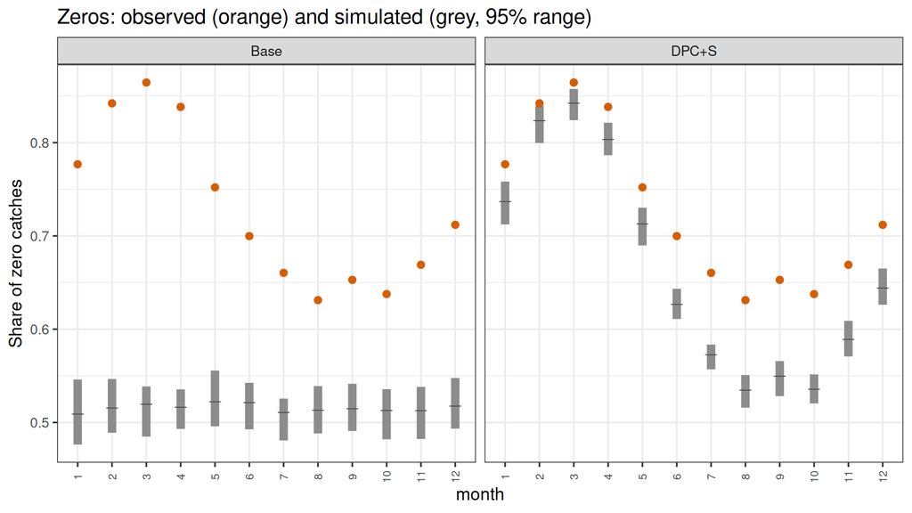

```r
pp_dol_m <- ppc_cpue(fit_dol, models = c("Base", "DPC+S"), by = "month")
pp_dol_m$plots$zeros
```

```r
pp_dol <- ppc_cpue(fit_dol, models = c("Base", "DPC+S"), by = "year")
pp_dol
```

```
## Predictive check: 50 replicates, with parameter uncertainty, tweedie
##
##  model  stat observed median  lower  upper tail_prob
##   Base zeros    0.715  0.515  0.507  0.527      0.00
##   Base  mean    0.954  0.961  0.923  0.989      0.64
##   Base   q90    9.610  4.610  4.460  4.760      0.00
##   Base   q99   25.800  9.730  9.130 10.100      0.00
##  DPC+S zeros    0.715  0.645  0.639  0.653      0.00
##  DPC+S  mean    0.954  0.960  0.938  0.979      0.74
##  DPC+S   q90    9.610  8.330  7.980  8.690      0.00
##  DPC+S   q99   25.800 17.800 16.900 18.600      0.00
```

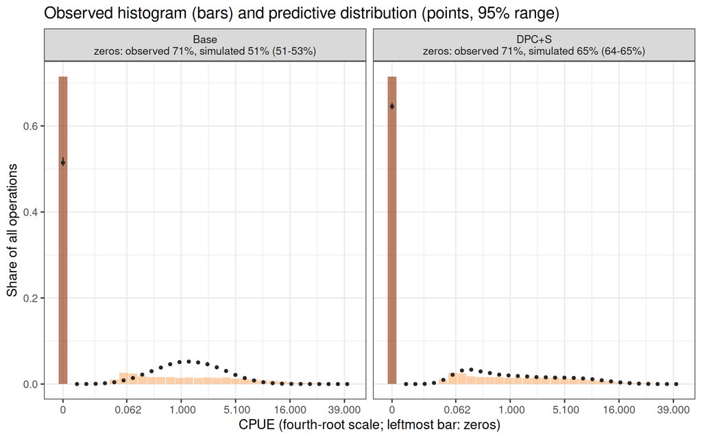

```r
pp_dol$plots$distribution
```

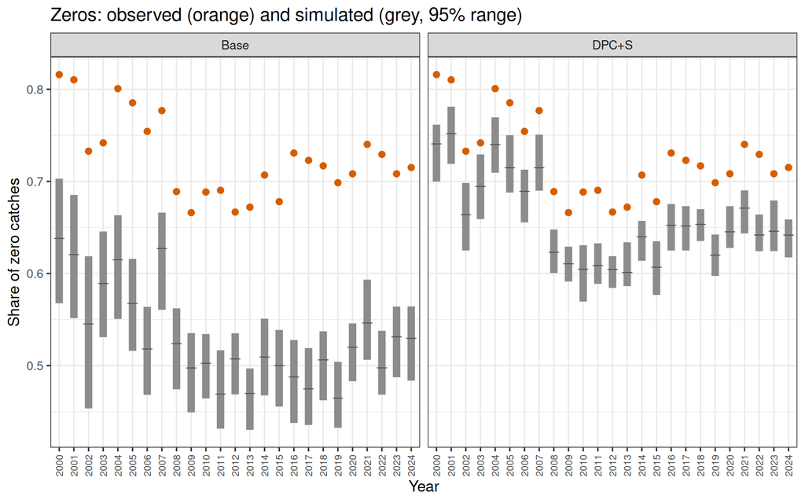

```r
pp_dol$plots$zeros
```

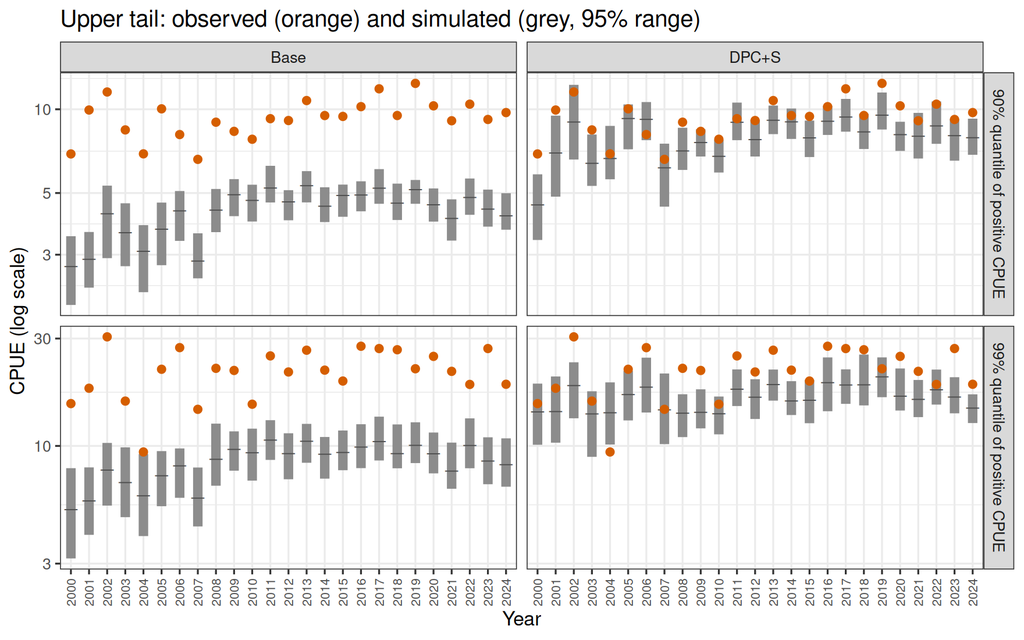

```r
pp_dol$plots$tails
```

### Error distribution: Tweedie or delta-lognormal?

A delta model lets the probability of a catch and the catch rate of positive trips change separately, e.g. when the season shortens. AIC cannot compare a Tweedie with a delta model, but a predictive check can:

```r
fit_dol_dl <- fit_cpue(xp, species = "Coryphaena hippurus", models = "DPC+S",
                       family = "delta_lognormal",
                       terms = 's(month, bs = "cc", k = 6)',
                       knots = list(month = c(0.5, 12.5)),
                       vessel = TRUE, spatial_k = 40, engine = "bam")
pp_dl <- ppc_cpue(fit_dol_dl, by = "month")
rbind(data.frame(family = "Tweedie",
                 pp_dol_m$overall[pp_dol_m$overall$model == "DPC+S", ]),
      data.frame(family = "delta-lognormal", pp_dl$overall))
```

```
##            family model group  stat   observed     median      lower      upper
## 5         Tweedie DPC+S   All zeros  0.7148126  0.6452125  0.6390602  0.6529452
## 6         Tweedie DPC+S   All  mean  0.9539995  0.9601213  0.9383178  0.9793335
## 7         Tweedie DPC+S   All   q90  9.6052632  8.3293553  7.9759213  8.6922379
## 8         Tweedie DPC+S   All   q99 25.7524357 17.8304106 16.9114787 18.5777129
## 1 delta-lognormal DPC+S   All zeros  0.7148126  0.7152552  0.7085036  0.7207952
## 2 delta-lognormal DPC+S   All  mean  0.9539995  1.1408306  1.0670850  1.2713289
## 3 delta-lognormal DPC+S   All   q90  9.6052632 10.0403629  9.1416388 10.9862446
## 4 delta-lognormal DPC+S   All   q99 25.7524357 44.9223675 39.4275724 53.2216513
##   tail_prob
## 5      0.00
## 6      0.74
## 7      0.00
## 8      0.00
## 1      0.58
## 2      1.00
## 3      0.88
## 4      1.00
```

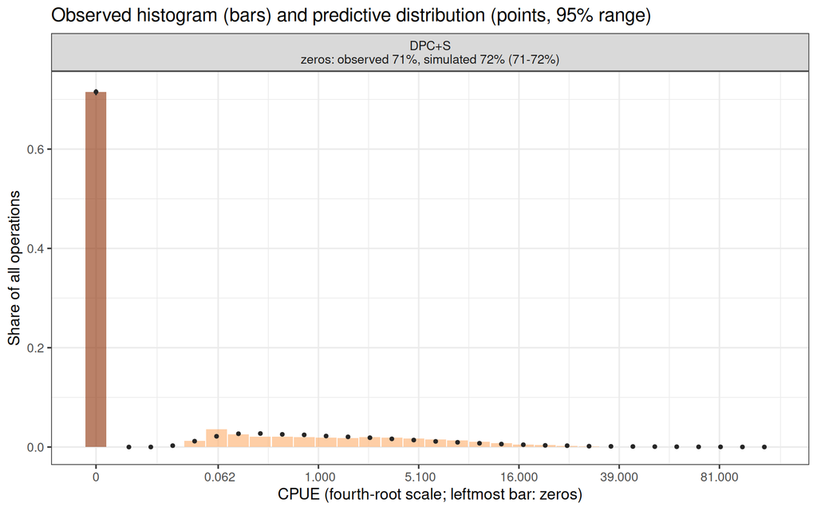

```r
pp_dl$plots$distribution
```

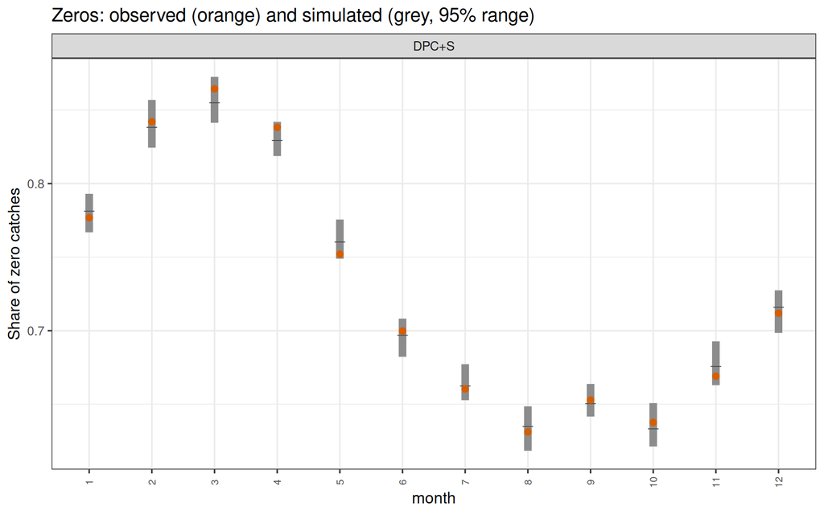

```r
pp_dl$plots$zeros
```

### Effects and vessels

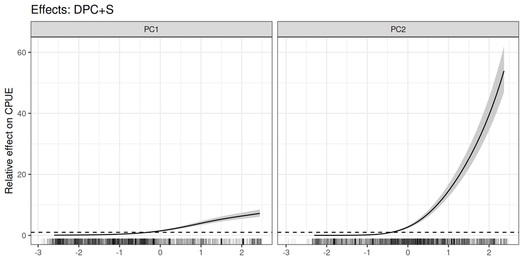

```r
eff_dol <- plot_effects(fit_dol, "DPC+S")
eff_dol$numeric
```

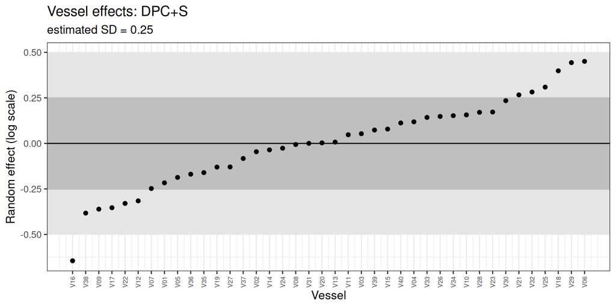

```r
plot_vessel_effects(fit_dol, "DPC+S")
```

### Sensitivity

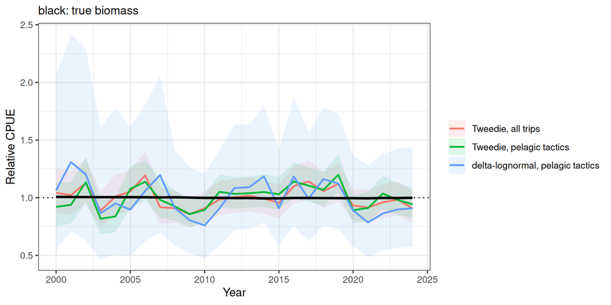

```r
fit_dol_all <- fit_cpue(x, species = "Coryphaena hippurus", models = "DPC+S",
                        terms = 's(month, bs = "cc", k = 6)',
                        knots = list(month = c(0.5, 12.5)),
                        vessel = TRUE, spatial_k = 40, engine = "bam")
compare_indices(list(`Tweedie, pelagic tactics` = list(fit = fit_dol, model = "DPC+S"),
                     `delta-lognormal, pelagic tactics` = list(fit = fit_dol_dl,
                                                              model = "DPC+S"),
                     `Tweedie, all trips` = list(fit = fit_dol_all, model = "DPC+S")),
                true_dol)
```

> **Guidelines: seasonal species**
> - Include the season (cyclic smoother) in all models except `Base`, and check the zeros by month with `ppc_cpue(..., by = "month")`.
> - Keep only trips that could catch the species; outside its season or habitat, zeros carry no information on abundance.
> - Choose the error distribution with predictive checks and residuals, not AIC across families; report the other family as a sensitivity.
> - Seasonal availability can shift between years with temperature; in real data a `month x year` interaction or a temperature covariate may be needed.

## Step 9. The index

```r
idx_dol <- cpue_index(fit_dol, "DPC+S")
knitr::kable(idx_dol, digits = 3)
```

| year | n | nominal | index | relative | se_log | cv | lower | upper |
| --- | --- | --- | --- | --- | --- | --- | --- | --- |
| 2000 | 239 | 0.481 | 0.052 | 0.920 | 0.104 | 0.104 | 0.751 | 1.128 |
| 2001 | 274 | 0.538 | 0.053 | 0.938 | 0.096 | 0.097 | 0.777 | 1.133 |
| 2002 | 232 | 1.001 | 0.064 | 1.134 | 0.088 | 0.088 | 0.955 | 1.347 |
| 2003 | 275 | 0.655 | 0.046 | 0.818 | 0.091 | 0.091 | 0.684 | 0.977 |
| 2004 | 296 | 0.552 | 0.047 | 0.838 | 0.093 | 0.093 | 0.699 | 1.005 |
| 2005 | 326 | 0.770 | 0.061 | 1.077 | 0.085 | 0.086 | 0.911 | 1.273 |
| 2006 | 415 | 0.941 | 0.064 | 1.138 | 0.078 | 0.078 | 0.977 | 1.325 |
| 2007 | 354 | 0.498 | 0.056 | 0.982 | 0.088 | 0.088 | 0.827 | 1.166 |
| 2008 | 569 | 0.872 | 0.052 | 0.925 | 0.072 | 0.073 | 0.802 | 1.066 |
| 2009 | 575 | 1.084 | 0.049 | 0.858 | 0.071 | 0.071 | 0.746 | 0.987 |
| 2010 | 597 | 0.957 | 0.051 | 0.894 | 0.070 | 0.071 | 0.778 | 1.026 |
| 2011 | 649 | 1.131 | 0.060 | 1.051 | 0.068 | 0.068 | 0.919 | 1.201 |
| 2012 | 690 | 0.976 | 0.059 | 1.033 | 0.068 | 0.069 | 0.903 | 1.182 |
| 2013 | 811 | 1.182 | 0.059 | 1.039 | 0.067 | 0.067 | 0.912 | 1.184 |
| 2014 | 805 | 1.020 | 0.059 | 1.050 | 0.068 | 0.068 | 0.918 | 1.200 |
| 2015 | 562 | 1.011 | 0.058 | 1.030 | 0.070 | 0.070 | 0.897 | 1.182 |
| 2016 | 650 | 0.998 | 0.065 | 1.140 | 0.069 | 0.070 | 0.995 | 1.306 |
| 2017 | 653 | 1.173 | 0.063 | 1.104 | 0.069 | 0.069 | 0.964 | 1.265 |
| 2018 | 724 | 0.974 | 0.061 | 1.068 | 0.070 | 0.070 | 0.932 | 1.225 |
| 2019 | 680 | 1.143 | 0.068 | 1.199 | 0.069 | 0.069 | 1.048 | 1.372 |
| 2020 | 802 | 0.984 | 0.051 | 0.892 | 0.069 | 0.069 | 0.780 | 1.021 |
| 2021 | 585 | 0.816 | 0.052 | 0.911 | 0.073 | 0.073 | 0.789 | 1.051 |
| 2022 | 628 | 0.942 | 0.059 | 1.036 | 0.070 | 0.071 | 0.902 | 1.190 |
| 2023 | 593 | 0.916 | 0.056 | 0.981 | 0.071 | 0.072 | 0.853 | 1.129 |
| 2024 | 572 | 0.929 | 0.053 | 0.943 | 0.072 | 0.072 | 0.819 | 1.086 |

# Processing logs

Every selection step is recorded, so the final data of each index can be reported exactly.

```r
xd$log
```

```
##                  step operations
## 1 input (long format)      19574
## 2              subset      19218
## 3      select species      19218
## 4       add targeting      19218
## 5      select tactics       5662
## 6       add targeting       5662
##                                                                                note
## 1                                                         46775 records, 10 species
## 2                                                  positions reported (356 removed)
## 3                                        10 of 10 species kept (occurrence >= 0.95)
## 4                      3 PC(s) used (OC test: 3), 4 clusters (clara on composition)
## 5 clusters 3, 4 kept (clusters with >= 50% of catch from 6 species) (13556 removed)
## 6                      4 PC(s) used (OC test: 4), 5 clusters (clara on composition)
```

```r
xp$log
```

```
##                  step operations
## 1 input (long format)      19574
## 2              subset      19218
## 3      select species      19218
## 4       add targeting      19218
## 5      select tactics      13556
## 6       add targeting      13556
##                                                                               note
## 1                                                        46775 records, 10 species
## 2                                                 positions reported (356 removed)
## 3                                       10 of 10 species kept (occurrence >= 0.95)
## 4                     3 PC(s) used (OC test: 3), 4 clusters (clara on composition)
## 5 clusters 1, 2 kept (clusters with >= 50% of catch from 4 species) (5662 removed)
## 6                     2 PC(s) used (OC test: 2), 3 clusters (clara on composition)
```

# Reporting checklist

| Item | Blackspot seabream | Dolphinfish |
| --- | --- | --- |
| Operation and effort | trip; hours fished | trip; hours fished |
| Data selection | positions reported; demersal tactics (`select_tactics`, >= 50% demersal catch) | positions reported; pelagic tactics (>= 50% pelagic catch) |
| Species set | 95% of occurrences, target kept | 95% of occurrences, target kept |
| Targeting | PCA of demersal trips, OC test, `n_pc + 1` clusters | PCA of pelagic trips, OC test, `n_pc + 1` clusters |
| Models | Base, Base+S, Cluster+S, DPC+S; random vessel effect; Tweedie | Base, Covariates (month), Cluster+S, DPC+S; random vessel effect; Tweedie and delta-lognormal |
| Diagnostics | model table, step, influence, residuals, predictive check (zeros by year) | as left, predictive check by month and year, family comparison |
| Sensitivity | all trips; Stephens & MacCall | all trips; delta-lognormal |
| Index | DPC+S with log SE and CV | DPC+S with log SE and CV |

# Things to try

- `logbook_settings()` lists every setting (see *Setting up the logbook simulator*). Change the prices, the closure, the share of two-set trips (`logbook$two_sets`) and how often they switch tactic (`logbook$switch_tactic`), the reef patches (`reef_share`, `reef_scale`), or the loyalty of specialists (`loyalty`), and see how each affects the targeting covariates and the indices.
- Compare `n_pc` and the number of clusters, and the species set (`select_species(..., pool_other = TRUE)`).
- Define an indicator fleet with `select_vessels(..., target = ...)` and compare the indices.
- Give the species diverging trends (`B_start`, `r`) and check whether the PCs start absorbing them.

# References

Bentley, N., Kendrick, T.H., Starr, P.J. and Breen, P.A. (2012) Influence plots and metrics: tools for better understanding fisheries catch-per-unit-effort standardizations. ICES Journal of Marine Science 69: 84-88.

Dunn, P.K. and Smyth, G.K. (1996) Randomized quantile residuals. Journal of Computational and Graphical Statistics 5: 236-244.

Gelman, A., Meng, X.-L. and Stern, H. (1996) Posterior predictive assessment of model fitness via realized discrepancies. Statistica Sinica 6: 733-807.

Hoyle, S.D., Langley, A.D. and Campbell, R.A. (2014) Recommended approaches for standardizing CPUE data from pelagic fisheries. WCPFC-SC10-2014/SA-IP-10.

Stephens, A. and MacCall, A. (2004) A multispecies approach to subsetting logbook data for purposes of estimating CPUE. Fisheries Research 70: 299-310.

Winker, H., Kerwath, S.E. and Attwood, C.G. (2013) Comparison of two approaches to standardize catch-per-unit-effort for targeting behaviour in a multispecies hand-line fishery. Fisheries Research 139: 118-131.

Winker, H., Kerwath, S.E. and Attwood, C.G. (2014) Proof of concept for a novel procedure to standardize multispecies catch and effort data. Fisheries Research 155: 149-159.